# Developing Efficient Scorers in the NBA: Which teams do it the best?

Benjamin Thorpe

12-18-2023

# Introduction

In the contemporary landscape of the National Basketball Association (NBA), the ability of teams to develop players’ offensive skills has become a focal point of team strategy and success. This emphasis stems from the evolving nature of the game, where player’s offensive versatility and efficiency have become paramount to earning playing time. As the pace of play has increased in every season but one going back to 2012-2013 (Scaletta), having players who can maintain strong efficiency numbers while the volume of shots taken continues to increase year over year is essential for teams looking to be successful. Additionally, as the use of analytics has become widely accepted in the league over the past 15 years, the number of three point shot attempts taken every year has went up in each season since 2010-2011 (Wal). This reliance on shooting has meant a transition to more guard-heavy and “small-ball” lineups and a decline in teams building around a dominant big man, which is demonstrated by guards “using” almost 50% of offensive possesions in the NBA as of 2018 (Thinking). Here, this usage rate is defined as “the proportion of possessions used by a player by either shooting, winning free throws, or committing a turnover” (Thinking).

With these trends in mind, I want to determine if any teams stand out, either positively or negatively, in developing their players’ offensive game. I will be focusing on the development of more guard-related attributes in this study, however as the league continues to see an influx of taller athletes with guard-like skills, it should be noted that these abilities can be improved upon by all NBA players. Also, I am interested in how a set of player-level variables affect the development of each of these skills, and this will be an additional question I answer. In regards to which skills I will focus on, I will be examining the play types of isolation, pick and roll ball handler, and spot-up shooter to try and identify which teams are the best at developing these specific skills, as each is an important part of offense in the NBA today. Isolation plays, which rely on a player’s ability to score one-on-one, demand high skill levels in ball-handling, shooting, and decision-making. Similarly, proficiency in the pick and roll as a ball handler necessitates a blend of vision, timing, and scoring ability, making it a cornerstone of modern offensive systems. Meanwhile, the spot-up shooter role, critical for spacing the floor and capitalizing on defensive lapses, hinges on precise shooting and quick decision-making. The teams that excel in cultivating these skills not only enhance their offensive firepower but also gain a tactical edge. This ability to develop offensive prowess in players aligns with the league’s shift towards a more dynamic, fast-paced, and perimeter-oriented style of play, as discussed above. Consequently, identifying which NBA teams are best at developing these specific skills provides insights into their potential for long-term success and adaptability in an ever-changing basketball environment. This analysis not only reflects on the teams’ coaching and training methodologies but also on their talent scouting and player utilization strategies, making it a multifaceted and critical aspect of understanding team dynamics and future prospects in the league.

# Data Description

For my analysis, I am using the “NBA_Play_Types_16_23” dataset available on Dominic Samangy’s github page (DomSamangy). Dominic is currently an analyst for the New Orleans Pelicans and has over time created a great set of sports analytics resources on a google sheet called [“Guide to Sports Analytics”](https://docs.google.com/spreadsheets/d/1LPe8xYduoep9qCrNzBGdJHaHZ8dnmdHNnu7UXZKzawU/edit#gid=145377427), and I found this set of data, which he scraped and uploaded into a csv, from the “Data Resources” tab.

The data itself comes from NBA.com, which has an immense database of all different kinds of basketball statistics from the NBA. The play type data I will be utilizing here is via Synergy Sports (though publicly available on NBA.com), and at a high level contains data describing how well players perform when they are involved in different play types over the course of a season, and comprises data from the 2015-2016 to 2022-2023 seasons. A row will contain a player’s identifying information, the season which the data is from, a certain play type, their points per possession (PPP, explained in more detail below) and its associated percentile in that season, and multiple other metrics such as games played, effective field goal percentage (shooting percentage that adjusts for 3-point shots being worth 50% more), percentage of times free throws were attempted, and percentage of times a turnover was committed, which I will use as variables I hold constant in my model. From domain knowledge I believe each of the above statistics when combined can give a good overview of the offensive level a player is at, and thus are important to account for when judging team’s player development abilities. There are also a few other statistics that I will not be using in my analysis. There are 11 different play type categories, however I will only be focusing on three as mentioned in the introduction to specifically look at a few key areas of offense. How efficient a player is at a given play type is defined here by their PPP, which is the average points per possession of that player, in that play type, in that year. So if on all possessions in a season where a player takes a catch and shoot shot their team scores an average of 1.2 points, this would be their PPP for their “spotup” row. The change in PPP from one year to the next will be my response variable.

As far as data cleaning, I mostly kept the dataset as is besides filtering for my three play types of interest. The only additional change I made was excluding rows where a player had fewer than 20 possessions of a certain play type in a given season, as below this mark there were many outliers that may have skewed my findings (though this was chosen arbitrarily). My goal here is to determine which teams have the best offensive development program, and including data on extremely small sample sizes from players would not be beneficial as my response variable is an average over a season, and thus does not take frequency into account since I want to maintain a focus on efficiency. This resulted in a final dataframe with 5,193 observations which I used to complete my analysis.

# Exploratory Data Analysis

First, let’s visualize the PPP distirbution for each play type:

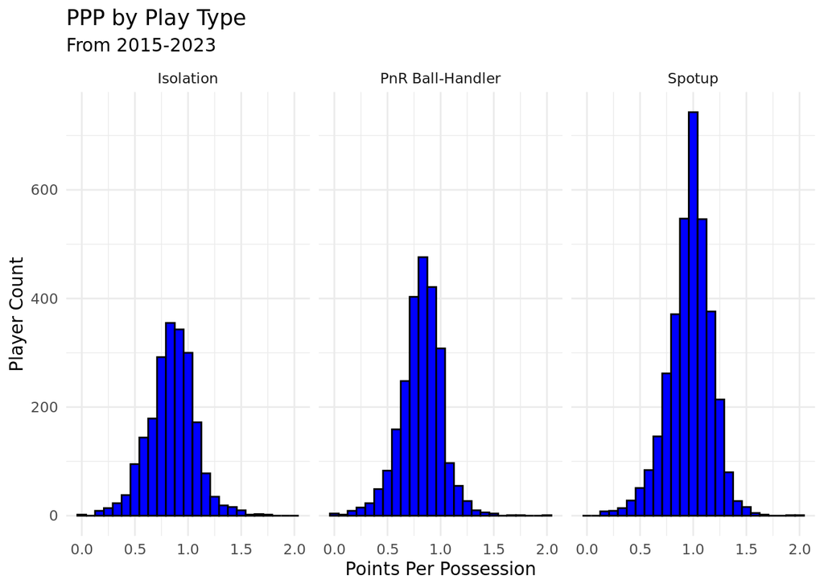

Now, let’s look at how a player’s skill in each of these three categoried changes, on average, from year to year:

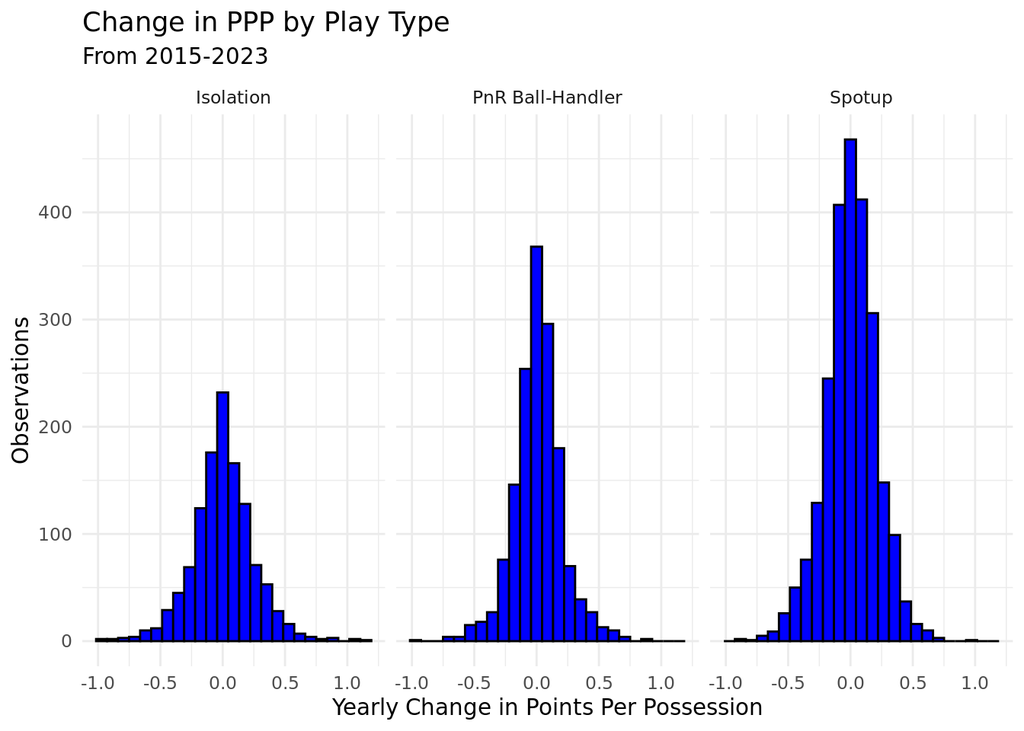

Somewhat surprisingly, these histograms exhibit the finding that the majority of NBA players do not improve on these skills year-to-year. I would have expected the center of the distributions to be sightly higher than zero with players working year-round to improve their game, however clearly this is not the case. This makes the priority of my research even more important, as consistently having players get better over time will give teams able to achieve this a substantial leg up over their opponents.

As the final part of my EDA, I wanted to take a look at an example of what good player development looks like.

Tyrese Haliburton

| PLAY_TYPE | 2020-21_PPP | 2020-21_POSS | 2022-23_PPP | 2022-23_POSS |
| --- | --- | --- | --- | --- |
| Isolation | 0.70 | 27 | 0.91 | 105 |
| PnR Ball-Handler | 0.95 | 283 | 1.04 | 495 |
| Spotup | 1.13 | 187 | 1.20 | 128 |

# Methodology

I am employing a random intercepts linear model to analyze the influence of team-level factors on individual player development in offensive play among three play types: isolations, the ball handler in pick and rolls, and spotups. This modeling choice is driven by the hierarchical nature of the data, where player-level statistics (level one predictors) are nested within teams (level two random intercepts). The response variable in this analysis is a player’s Points Per Possession (PPP) for a specified play type, which, as established in the exploratory data analysis (EDA), follows a normal distribution.

At the first level of the model, the predictor variables are drawn from a player’s statistics related to their involvement in a particular play type within a single season. These variables are chosen for their relevance in quantifying a player’s current skill level and stage in their career, offering a comprehensive baseline for assessing their offensive capabilities.

PPP (Points Per Possession): This metric is a direct measure of a player’s offensive efficiency. Including it as a predictor allows for assessing how past performance in terms of scoring efficiency influences future performance, under the premise that a player’s past efficiency is indicative of their skill level.

GP (Games Played): This variable indicates the extent of a player’s involvement in the game. It serves as a proxy for experience and endurance, assuming that more game time translates to more opportunities for development and contribution.

EFG_PCT (Effective Field Goal Percentage): This statistic adjusts the standard field goal percentage to account for the fact that three-point field goals are worth more than two-point field goals. It’s a crucial measure of shooting efficiency, reflecting a player’s ability to score points more effectively.

FTA_FREQ (Free Throw Attempt Frequency): This represents the frequency of free throw attempts relative to the player’s overall play. It’s an important aspect of scoring efficiency, highlighting a player’s ability to draw fouls and capitalize on free-throw opportunities.

TOV_FREQ (Turnover Frequency): This is the frequency of turnovers per play. It’s essential to consider this in evaluating a player’s offensive development, as minimizing turnovers is key to maximizing scoring opportunities and maintaining offensive efficiency.

FREQ (Frequency): This measures how often a player is involved in the specified play type. It indicates a player’s role and involvement in the team’s offensive strategies, providing context to their PPP.

At the second level, the random intercept for each team (TEAM_ABB) accounts for the team’s overarching influence on a player’s development. This aspect of the model captures the effect of team-specific factors such as coaching and team dynamics that are pivotal in player development but are not directly measured in the dataset.

By incorporating these player-level variables and a team-level random intercept, the model aims to isolate the impact of a team’s ability to enhance offensive skills, controlling for individual player attributes and career stage factors. This approach allows for a nuanced understanding of how different teams contribute to or detract from their players’ offensive development in the NBA.

The full model in mathematical notation is displayed below:

$$PPP_{next_{ij}} = \beta_0 + u_{0j} + \beta_1 \times PPP_{ij} + \beta_2
\times GP_{ij} + \beta_3 \times EFG\_PCT_{ij} + \beta_4 \times
FTA\_FREQ_{ij} + \beta_5 \times TOV\_FREQ_{ij} + \beta_6 \times
FREQ_{ij} + \varepsilon_{ij}$$

$$\epsilon_{ij} \sim N(0, \sigma^2),
u_{0j} \sim N(0, \sigma_u^2)$$

Where $PPP_{next_{ij}}$ is the points per possession for the next season for player $i$ on team $j$, $\beta_1 - \beta_6$ are the fixed effect coefficients for the respective level one predictors, $GP_{ij}, EFG\_PCT_{ij}, FTA\_FREQ_{ij}, TOV\_FREQ_{ij}, FREQ_{ij}$ are the player-level predictor variables for player $i$ on team $j$, $u_{0j}$ is the random intercept for team $j$ (captures the team-level component) and $\varepsilon_{ij}$ is the residual error term for player $i$ on team $j$. Both error terms are assumed to follow a normal distribution centered at zero.

# Results

The random intercepts model was implemented using the `lmer` function from the `lme4` package, and the outputs for each of the three models (one for each play type) are shown below:

Isolations

| effect | group | term | estimate | std.error | statistic |
| --- | --- | --- | --- | --- | --- |
| fixed | NA | (Intercept) | 0.713 | 0.046 | 15.671 |
| fixed | NA | PPP | 0.315 | 0.145 | 2.167 |
| fixed | NA | GP | 0.000 | 0.000 | -0.496 |
| fixed | NA | EFG_PCT | -0.352 | 0.243 | -1.448 |
| fixed | NA | FTA_FREQ | -0.119 | 0.141 | -0.839 |
| fixed | NA | TOV_FREQ | 0.107 | 0.176 | 0.606 |
| fixed | NA | FREQ | 0.568 | 0.117 | 4.861 |
| ran_pars | TEAM_ABB | sd__(Intercept) | 0.018 | NA | NA |
| ran_pars | Residual | sd__Observation | 0.198 | NA | NA |

Pick and Rolls

| effect | group | term | estimate | std.error | statistic |
| --- | --- | --- | --- | --- | --- |
| fixed | NA | (Intercept) | 0.511 | 0.043 | 11.942 |
| fixed | NA | PPP | 0.930 | 0.149 | 6.241 |
| fixed | NA | GP | 0.000 | 0.000 | 1.423 |
| fixed | NA | EFG_PCT | -1.137 | 0.237 | -4.789 |
| fixed | NA | FTA_FREQ | -0.248 | 0.142 | -1.745 |
| fixed | NA | TOV_FREQ | 0.382 | 0.154 | 2.478 |
| fixed | NA | FREQ | 0.076 | 0.031 | 2.490 |
| ran_pars | TEAM_ABB | sd__(Intercept) | 0.014 | NA | NA |
| ran_pars | Residual | sd__Observation | 0.167 | NA | NA |

Spotups

| effect | group | term | estimate | std.error | statistic |
| --- | --- | --- | --- | --- | --- |
| fixed | NA | (Intercept) | 0.591 | 0.029 | 20.509 |
| fixed | NA | PPP | 1.155 | 0.174 | 6.634 |
| fixed | NA | GP | 0.000 | 0.000 | 1.954 |
| fixed | NA | EFG_PCT | -1.475 | 0.323 | -4.571 |
| fixed | NA | FTA_FREQ | -0.921 | 0.146 | -6.290 |
| fixed | NA | TOV_FREQ | 0.729 | 0.210 | 3.463 |
| fixed | NA | FREQ | -0.020 | 0.026 | -0.771 |
| ran_pars | TEAM_ABB | sd__(Intercept) | 0.005 | NA | NA |
| ran_pars | Residual | sd__Observation | 0.175 | NA | NA |

In examining the factors that influence player performance in the three play types in my analysis, our linear mixed-effects models reveal several key insights. Most notably, the coefficient for PPP (Points Per Possession) has a relatively large test statistic (though notably not as high in isolations) as well as a positive coefficient in each of the three models, and this suggests a statistically significant positive effect on the response variable. This implies that an increase in PPP in a play type is associated with an improvement in the player’s performance in that same play type the following season, which follows conventional wisdom that players with a relatively high PPP in a certain play type are more likely to be effificent the following season compared to a player with a lower PPP. In the case of isolations, we can expect a player’s next year’s PPP in this play type to increase by about 0.0315 for every additional 0.1 increase in his current season PPP, holding the other level-one predictors as well as the team he is on constant. The statistical significance of the other level one predictors vary across the three models, and I will examine these differences and what they might mean in relation to the research problem in the analysis and conclusions part of the paper. The random effects associated with a player’s team suggest that there are team-specific influences on player performance that are not captured by the player-level predictors. Lastly, the residual standard deviation, which reflects the variability in the response variable not explained by the model, is large in each model within the context of the data. Looking again at the isolations play type output, 0.198 PPP is a huge difference in terms of the efficiency of a player (demonstrated by the distibutions of PPP in the EDA), and is an important finding to analyze as a takeaway from this study.

Isolations

| TEAM_ABB | Random_Intercept |
| --- | --- |
| PHI | 0.015 |
| GSW | 0.012 |
| ATL | 0.011 |
| CHA | 0.011 |
| HOU | 0.010 |
| DEN | 0.007 |

We can see that from 2015-2023, the Philadelphia 76ers were the best team at developing efficient isolation scorers by this method of evaluation. We can interpret this random intercept of around 0.015 as: for a given NBA player, we would expect them to improve their PPP on isolations in the following season by 0.015, on average, if they are a part of the 76ers compared to if they were not being developed by an NBA team. Although not seen here, there are negative random intercepts that appear across the three models, which can be interpreted as teams actually hindering their players’ ability to develop offensively. I will delve into what teams stand out as either positive or negative in this regard in the next section.

# Analysis and Conclusion

In what was definitely a surprise to me, there was not too much overlap among the top teams when looking across the random intercepts from the three play types analyzed. I had hypothesized that some of the teams known for their great player development, such as the Miami Heat (Zillgitt), would appear near the top of each of these lists, however the Heat had an almost negligible impact in every case (possible reasons why discussed in Limitations). With that being said, the standout team for me was the Philadelphia 76ers. They had a random intercept of 0.015 (ranked 1st) in the isolations model and one of 0.006 (ranked 4th) in the pick and roll ball-handlers model, and were the only team to be top five in both (spotups had essentially no teams with a strong influence positively or negatively which is looked at in detail later in this section). This checks out, as over the time period the data is from the 76ers have emerged as a consistent threat to win the Eastern conference, and even produced the league’s Most Valuable Player last year in Joel Embiid. On the flip side, two teams that popped on the negative side are the Pistons and Lakers. First looking at the Pistons, they placed last and second-to-last, respectively, in the isolations and pick and roll ball handlers models, which goes along perfectly with their status as the consensus worst franchise in the NBA. They have fluctuated between below-average and awful since 2015, and their lack of offensive player development has been clear through these times. The Lakers, on the other hand, have been mostly successful since LeBron James (one of the best basketball players of all time) joined the team in 2018, however they were really bad in the years prior to his arrival. I suspect their poor standing in developing isolation scorers and pick and roll ball handlers stems from both those three years before LeBron when the team lacked a clear direction as well as the lack of skill improvement that is expected by a team full of veterans. After signing with the Lakers, James made a strong push to the Lakers front office to surround him with experienced players he could trust in the playoffs, and with him and fellow star Anthony Davis (who developed primarily while on the New Orleans Pelicans before being traded to the Lakers) carrying the load there was not much room for these relatively older players to develop offensively. The Pistons and Lakers examples exhibit the importance of context in this analysis, as the most likely reasons for their respective random intercepts are in reality very different from one another.

Moving on to the second part of my conclusions, analyzing the model outputs for the three different play types of isolations, spotups, and pick and rolls provides a multifaceted view of the factors contributing to a player’s offensive efficiency in the NBA, and there are a few key points from this I want to analyze in addition to the above team-centric findings:

The Points Per Possession (PPP) coefficient is particularly telling across all models as discussed in the results, though it is interesting to note that it is comparatively smaller in the isolation model, suggesting that current season efficiency might have a slightly less pronounced impact on the following season’s performance in this play type. The variability in the significance and magnitude of other level-one predictors across the models invites further investigation. For example, the Frequency (FREQ) variable stands out in the Isolations model with a much larger coefficient compared to the Spot-ups and Pick and Rolls. This could suggest that gaining experience specifically in isolation plays has a more substantial impact on a player’s subsequent performance in these scenarios.

Looking at team effects, the random intercept standard deviation in the spotups model is notably smaller than in the other models, implying that the team’s ability to influence player development in spot-up shooting may be more limited. This could point to the idea that shooting proficiency may be a skill less amenable to improvement through team interventions, as opposed to ball-handling and decision-making skills, which seem to be more significantly influenced by the team environment.

I noticed that an unexpected dichotomy arises between the Free Throw Attempt Frequency (FTA_FREQ) and the Turnover Frequency (TOV_FREQ) coefficients across all models. Contrary to initial assumptions, FTA_FREQ consistently shows a negative relationship with the response variable, indicating that more frequent trips to the free-throw line in the current season do not necessarily predict better offensive efficiency in the subsequent season. Conversely, TOV_FREQ has a positive coefficient in all models, suggesting that players with higher turnover rates might be involved in more dynamic plays, which could contribute to better performance in the long run, though this warrants a deeper exploration to fully understand the underlying dynamics.

The residual standard deviation, reflecting unexplained variability, is substantial across all models. Considering the distribution of PPP in the exploratory data analysis, this unexplained variability is a critical aspect of player performance that should be a focus of continued research.

This research has demonstrated that while PPP remains a consistent predictor of future performance across play types, the influence of other predictors and the team’s role in player development vary, offering rich avenues for further analysis. The models suggest that while teams can influence certain aspects of a player’s development, individual characteristics and the nature of the play type itself play pivotal roles in determining a player’s offensive evolution. The findings underscore the complexity of player development in the NBA and highlight the need for tailored approaches to player training and development strategies.

# Limitations

The current study, while providing valuable insights into the factors influencing player performance across different play types in the NBA, is subject to several limitations that merit consideration. First off, the analysis does not account for player development that occurs outside the NBA, such as through the G-League, which can significantly contribute to a player’s efficiency upon entering the NBA. Such developmental progress, reflective of a team’s broader developmental capabilities, remains outside the purview of this study, as it focuses solely on data derived from NBA games. Moreover, there are additional player-specific variables that could be valuable in controlling for the analysis, such as age, years of experience, and tenure with the current team. While the exclusion of these variables was a deliberate choice to neutrally assess developmental stages, it is plausible that players may exhaust a team’s developmental resources differently over time. For instance, a player’s growth trajectory might be more pronounced in their formative years with a team compared to subsequent seasons. The influence of the coaching staff, which can significantly impact a team’s ability to nurture offensive talent, is also not captured within this study. Given that coaching strategies and philosophies vary widely and coaches themselves may change frequently within a franchise, this represents a considerable factor that could sway the development of a player’s offensive skill set. Lastly, the scope of the analysis is confined to three specific play types. While these play types are critical to understanding aspects of offensive efficiency, they do not provide an exhaustive view of the complex nature of developing a player’s offensive capabilities. As such, the study offers a snapshot rather than a complete picture of the offensive development landscape within the NBA. Recognizing these limitations is essential for contextualizing the findings and for guiding future research, which could integrate a more holistic dataset that encompasses a wider range of developmental contexts and a broader spectrum of offensive play types.

# Future Study

Furthermore, integrating a mechanism to account for coaching changes would be a significant enhancement to the analysis. Coaching staff play a pivotal role in player development, and their influence can vary markedly from one coach to another. By tracking coaching tenures and correlating them with changes in player performance, a future study could offer a more dynamic and current appraisal of a team’s capability to foster offensive talent. This would also allow for the disentanglement of the effects of team environment and coaching strategies on player development, contributing to a more sophisticated understanding of how teams can enhance their players’ offensive prowess in the NBA.

# Citations

Scaletta, Kelly. “Why NBA Game Pace Is Historicically High”. Lineups.com. https://www.lineups.com/articles/why-nba-game-pace-is-at-historic-high/

Thinking Machines Data Science. “A whole new ball game: Quantifying changes in NBA basketball over the past 30 years”. https://stories.thinkingmachin.es/nba-in-30-years/

Wal, Goding (2020). “How the NBA has changed in the past 20 years, and insights to win”. Medium.com. https://medium.com/@gwal325/how-the-nba-has-changed-in-the-past-20-years-and-insights-to-win-23f8e9f17643

Zillgitt, Jeff (2023). “Heat’s secret sauce to building a winning roster includes dash of undrafted players”. USA Today. https://www.usatoday.com/story/sports/nba/heat/2023/06/03/heats-nba-finals-march-made-possible-by-developing-undrafted-players/70284775007/

# Appendix

Full model summaries:

```
## Linear mixed model fit by REML ['lmerMod']
## Formula: PPP_next ~ PPP + GP + EFG_PCT + FTA_FREQ + TOV_FREQ + FREQ +
##     (1 | TEAM_ABB)
##    Data: filter(nba_data_clean, PLAY_TYPE == "Isolation")
##
## REML criterion at convergence: -444.2
##
## Scaled residuals:
##     Min      1Q  Median      3Q     Max
## -4.2775 -0.5564  0.0354  0.6325  4.5822
##
## Random effects:
##  Groups   Name        Variance Std.Dev.
##  TEAM_ABB (Intercept) 0.000316 0.01778
##  Residual             0.039055 0.19762
## Number of obs: 1189, groups:  TEAM_ABB, 30
##
## Fixed effects:
##               Estimate Std. Error t value
## (Intercept)  0.7134006  0.0455248  15.671
## PPP          0.3146628  0.1452124   2.167
## GP          -0.0001748  0.0003529  -0.496
## EFG_PCT     -0.3516309  0.2428799  -1.448
## FTA_FREQ    -0.1185222  0.1412637  -0.839
## TOV_FREQ     0.1065693  0.1758904   0.606
## FREQ         0.5678768  0.1168308   4.861
##
## Correlation of Fixed Effects:
##          (Intr) PPP    GP     EFG_PC FTA_FR TOV_FR
## PPP      -0.522
## GP       -0.500 -0.027
## EFG_PCT   0.364 -0.969  0.045
## FTA_FREQ  0.244 -0.719 -0.008  0.695
## TOV_FREQ -0.555  0.756 -0.027 -0.734 -0.556
## FREQ     -0.083 -0.092  0.007  0.053 -0.025  0.004
```

```
## Linear mixed model fit by REML ['lmerMod']
## Formula: PPP_next ~ PPP + GP + EFG_PCT + FTA_FREQ + TOV_FREQ + FREQ +
##     (1 | TEAM_ABB)
##    Data: filter(nba_data_clean, PLAY_TYPE == "PnR Ball-Handler")
##
## REML criterion at convergence: -1117.9
##
## Scaled residuals:
##     Min      1Q  Median      3Q     Max
## -4.7299 -0.5013  0.0585  0.5646  4.3595
##
## Random effects:
##  Groups   Name        Variance  Std.Dev.
##  TEAM_ABB (Intercept) 0.0001914 0.01384
##  Residual             0.0277305 0.16652
## Number of obs: 1554, groups:  TEAM_ABB, 30
##
## Fixed effects:
##               Estimate Std. Error t value
## (Intercept)  0.5105820  0.0427552  11.942
## PPP          0.9298486  0.1490011   6.241
## GP           0.0003073  0.0002159   1.423
## EFG_PCT     -1.1370697  0.2374183  -4.789
## FTA_FREQ    -0.2476016  0.1419188  -1.745
## TOV_FREQ     0.3815393  0.1539592   2.478
## FREQ         0.0762826  0.0306395   2.490
##
## Correlation of Fixed Effects:
##          (Intr) PPP    GP     EFG_PC FTA_FR TOV_FR
## PPP      -0.695
## GP       -0.234 -0.019
## EFG_PCT   0.558 -0.974  0.000
## FTA_FREQ  0.441 -0.773  0.016  0.742
## TOV_FREQ -0.767  0.876 -0.011 -0.843 -0.670
## FREQ     -0.061 -0.067  0.035  0.038  0.056 -0.062
```

```
## Linear mixed model fit by REML ['lmerMod']
## Formula: PPP_next ~ PPP + GP + EFG_PCT + FTA_FREQ + TOV_FREQ + FREQ +
##     (1 | TEAM_ABB)
##    Data: filter(nba_data_clean, PLAY_TYPE == "Spotup")
##
## REML criterion at convergence: -1537.9
##
## Scaled residuals:
##     Min      1Q  Median      3Q     Max
## -4.7561 -0.5430  0.0637  0.6061  5.5502
##
## Random effects:
##  Groups   Name        Variance  Std.Dev.
##  TEAM_ABB (Intercept) 2.821e-05 0.005311
##  Residual             3.078e-02 0.175453
## Number of obs: 2450, groups:  TEAM_ABB, 30
##
## Fixed effects:
##               Estimate Std. Error t value
## (Intercept)  0.5908362  0.0288088  20.509
## PPP          1.1545505  0.1740316   6.634
## GP           0.0003452  0.0001767   1.954
## EFG_PCT     -1.4753148  0.3227419  -4.571
## FTA_FREQ    -0.9214838  0.1464953  -6.290
## TOV_FREQ     0.7288808  0.2104901   3.463
## FREQ        -0.0202825  0.0262924  -0.771
##
## Correlation of Fixed Effects:
##          (Intr) PPP    GP     EFG_PC FTA_FR TOV_FR
## PPP      -0.517
## GP       -0.267 -0.001
## EFG_PCT   0.427 -0.992 -0.010
## FTA_FREQ  0.245 -0.714 -0.024  0.712
## TOV_FREQ -0.595  0.861  0.003 -0.845 -0.689
## FREQ     -0.190  0.001 -0.017 -0.010  0.108 -0.004
```

Random intercepts for each play type:

Isolations

| TEAM_ABB | Random_Intercept |
| --- | --- |
| PHI | 0.015 |
| GSW | 0.012 |
| ATL | 0.011 |
| CHA | 0.011 |
| HOU | 0.010 |
| DEN | 0.007 |
| NYK | 0.007 |
| OKC | 0.006 |
| CHI | 0.005 |
| MIN | 0.005 |
| WAS | 0.005 |
| SAC | 0.004 |
| POR | 0.004 |
| MIL | 0.003 |
| BKN | 0.002 |
| IND | 0.002 |
| CLE | 0.000 |
| UTA | -0.002 |
| MIA | -0.002 |
| TOR | -0.004 |
| LAC | -0.004 |
| ORL | -0.004 |
| NOP | -0.006 |
| SAS | -0.007 |
| BOS | -0.009 |
| LAL | -0.010 |
| PHX | -0.013 |
| MEM | -0.014 |
| DAL | -0.014 |
| DET | -0.018 |

Pick and Roll Ball-Handler

| TEAM_ABB | Random_Intercept |
| --- | --- |
| LAC | 0.015 |
| SAS | 0.010 |
| POR | 0.006 |
| PHI | 0.006 |
| MIL | 0.006 |
| PHX | 0.006 |
| BOS | 0.006 |
| UTA | 0.005 |
| DAL | 0.005 |
| DEN | 0.005 |
| IND | 0.004 |
| OKC | 0.003 |
| WAS | 0.002 |
| GSW | 0.002 |
| BKN | 0.001 |
| HOU | 0.001 |
| TOR | 0.001 |
| ORL | -0.001 |
| CLE | -0.002 |
| SAC | -0.002 |
| ATL | -0.002 |
| MEM | -0.002 |
| MIA | -0.002 |
| NOP | -0.004 |
| LAL | -0.006 |
| MIN | -0.007 |
| NYK | -0.012 |
| CHA | -0.012 |
| DET | -0.013 |
| CHI | -0.017 |

Spotups

| TEAM_ABB | Random_Intercept |
| --- | --- |
| SAC | 0.003 |
| SAS | 0.002 |
| WAS | 0.002 |
| BOS | 0.002 |
| PHX | 0.002 |
| PHI | 0.002 |
| POR | 0.001 |
| UTA | 0.001 |
| DAL | 0.001 |
| MIL | 0.001 |
| HOU | 0.001 |
| CHA | 0.000 |
| LAC | 0.000 |
| TOR | 0.000 |
| MEM | 0.000 |
| DEN | 0.000 |
| ORL | 0.000 |
| MIA | 0.000 |
| LAL | -0.001 |
| DET | -0.001 |
| IND | -0.001 |
| NYK | -0.001 |
| NOP | -0.001 |
| OKC | -0.001 |
| MIN | -0.001 |
| GSW | -0.001 |
| CHI | -0.002 |
| CLE | -0.002 |
| BKN | -0.002 |
| ATL | -0.003 |